# Project 1. Olimpic games

Mikhail Fofanov

24.10.2021

Here we can activate all essential packages for Project 1:

```r
library('dplyr')
library('ggplot2')
```

### Task 1

Type your data folder path in PATH:

```r
PATH = 'D:/IB2021_2022/R_statistics/BI_Stat_2021/olimpic_games_folder/data_folder'
```

Type your processed file name in PROCESSED_FILE_NAME:

```r
PROCESSED_FILE_NAME = '/processed_data'
```

Type your file extension in FILE_EXTENSION:

```r
FILE_EXTENSION = '.csv'
```

Construct full name to processed file:

```r
FULL_PROCESSED_FILE_NAME = paste(PATH, PROCESSED_FILE_NAME, FILE_EXTENSION, sep = "")
```

Here you can find the function which help us to combine all data tables with olympic athletes data in one table:

```r
merge_files_from_folder <- function(path, processed_file_name, file_extension) {
  full_processed_file_name = paste(path, processed_file_name, file_extension, sep = "")
  if (file_extension == '.csv' &
     full_processed_file_name %in% list.files(path=path, full.names = T) == F) {
  processed_data <- list.files(path=path, full.names = TRUE) %>%
  lapply(read_csv, show_col_types = FALSE) %>%
  bind_rows
  write.csv(processed_data, full_processed_file_name, row.names=FALSE)
  } else {
  print('Try to merge .csv files!')
  }
}
```

Let’s use this function. Here we go!

```r
merge_files_from_folder(PATH, PROCESSED_FILE_NAME, FILE_EXTENSION)
```

```
## [1] "Try to merge .csv files!"
```

Here we can read our combined data table and check that everything is OK with its readability

```r
olimpiad_file <- read.csv(FULL_PROCESSED_FILE_NAME)
olimpiad_file_nrow <- nrow(olimpiad_file)
str(olimpiad_file)
```

```
## 'data.frame':    271115 obs. of  15 variables:
##  $ ID    : num  1 2 3 4 5 5 5 5 5 5 ...
##  $ Name  : chr  "A Dijiang" "A Lamusi" "Gunnar Nielsen Aaby" "Edgar Lindenau Aabye" ...
##  $ Sex   : chr  "M" "M" "M" "M" ...
##  $ Age   : int  24 23 24 34 21 21 25 25 27 27 ...
##  $ Height: int  180 170 NA NA 185 185 185 185 185 185 ...
##  $ Weight: num  80 60 NA NA 82 82 82 82 82 82 ...
##  $ Team  : chr  "China" "China" "Denmark" "Denmark/Sweden" ...
##  $ NOC   : chr  "CHN" "CHN" "DEN" "DEN" ...
##  $ Games : chr  "1992 Summer" "2012 Summer" "1920 Summer" "1900 Summer" ...
##  $ Year  : int  1992 2012 1920 1900 1988 1988 1992 1992 1994 1994 ...
##  $ Season: chr  "Summer" "Summer" "Summer" "Summer" ...
##  $ City  : chr  "Barcelona" "London" "Antwerpen" "Paris" ...
##  $ Sport : chr  "Basketball" "Judo" "Football" "Tug-Of-War" ...
##  $ Event : chr  "Basketball Men's Basketball" "Judo Men's Extra-Lightweight" "Football Men's Football" "Tug-Of-War Men's Tug-Of-War" ...
##  $ Medal : chr  NA NA NA "Gold" ...
```

### Task 2

Let’s check for NA in each columns:

```r
na_check_table <- data.frame(sapply(olimpiad_file, function(x) sum(is.na(x))))
colnames(na_check_table) <- c("NA number")
na_check_table
```

```
##        NA number
## ID             0
## Name           1
## Sex            2
## Age         9476
## Height     60172
## Weight     62876
## Team           3
## NOC            4
## Games          5
## Year           7
## Season         7
## City           7
## Sport          7
## Event          8
## Medal     231333
```

We can notice, that most of the NAs are detected in Age, Height and Weight columns.

It means, that we can not to just delete these rows without any effects unlike rows with NAs in other columns.

Let’s check Age column for any outliers and strange behaviour

```r
summary(olimpiad_file$Age)
```

```
##    Min. 1st Qu.  Median    Mean 3rd Qu.    Max.    NA's
##   10.00   21.00   24.00   25.56   28.00  240.00    9476
```

Unexpectedly, we found a lot of sportsmen comparing in ‘Art Competitions’ but it is not an olympic game discipline, so we decided to disqualify them.

We found also one outlier aged 240 years:

```r
olimpiad_file %>% filter(!is.na(Age), Age > 80, Sport != 'Art Competitions')
```

```
##      ID                       Name Sex Age Height Weight    Team NOC
## 1 23459 Flicien Jules mile Courbet   M 240     NA     NA Belgium BEL
##         Games Year Season      City    Sport
## 1 1912 Summer 1912 Summer Stockholm Swimming
##                                    Event Medal
## 1 Swimming Men's 200 metres Breaststroke  <NA>
```

It was decided to replace all NA in Age, Weight and Height columns with its average values in sex specific manner

Lets do it for Age column and check the summary:

```r
mean_F <- mean(olimpiad_file$Age[olimpiad_file$Sex == 'F'], na.rm=TRUE)
mean_M <- mean(olimpiad_file$Age[olimpiad_file$Sex == 'M'], na.rm=TRUE)

olimpiad_file_with_Age_na_replaced_F <- olimpiad_file %>%
  filter(Sex == 'F') %>%
  mutate(Age = ifelse(is.na(Age), mean_F, Age)) %>%
  filter(Age < 80, Sport != 'Art Competitions')

olimpiad_file_with_Age_na_replaced_M <- olimpiad_file %>%
  filter(Sex == 'M') %>%
  mutate(Age = ifelse(is.na(Age), mean_M, Age)) %>%
  filter(Age < 80, Sport != 'Art Competitions')


olimpiad_file_with_Age_na_replaced <-rbind(olimpiad_file_with_Age_na_replaced_F,
                                           olimpiad_file_with_Age_na_replaced_M)
summary(olimpiad_file_with_Age_na_replaced$Age)
```

```
##    Min. 1st Qu.  Median    Mean 3rd Qu.    Max.
##   10.00   22.00   25.00   25.34   28.00   72.00
```

Summary looks normal now, Age basics statistics almost unchanged after NA replacement

```r
olimpiad_file_nrow_Age_filtered <- nrow(olimpiad_file_with_Age_na_replaced)
proportion_nrow_Age_filtered <- round(olimpiad_file_nrow_Age_filtered / olimpiad_file_nrow * 100, 2)
cat("After Age column filtering,", olimpiad_file_nrow_Age_filtered, "rows were retained,", proportion_nrow_Age_filtered,"% from the original olympic games data table")
```

```
## After Age column filtering, 267527 rows were retained, 98.68 % from the original olympic games data table
```

Let’s check for other possible strange kinds of sport like ‘Art Competitions’

```r
summary(as.factor(olimpiad_file_with_Age_na_replaced$Sport))
```

```
##               Aeronautics             Alpine Skiing                  Alpinism
##                         1                      8829                        25
##                   Archery                 Athletics                 Badminton
##                      2334                     38623                      1457
##                  Baseball                Basketball             Basque Pelota
##                       894                      4535                         2
##          Beach Volleyball                  Biathlon                 Bobsleigh
##                       564                      4893                      3058
##                    Boxing                  Canoeing                   Cricket
##                      6047                      6170                        24
##                   Croquet      Cross Country Skiing                   Curling
##                        19                      9133                       463
##                   Cycling                    Diving             Equestrianism
##                     10859                      2842                      6344
##                   Fencing            Figure Skating                    Footba
##                     10734                      2298                         1
##                  Football          Freestyle Skiing                      Golf
##                      6743                       937                       247
##                Gymnastics                  Handball                    Hockey
##                     26706                      3664                      5416
##                Ice Hockey              Jeu De Paume                      Judo
##                      5516                        11                      3801
##                  Lacrosse                      Luge       Military Ski Patrol
##                        60                      1479                        24
##         Modern Pentathlon              Motorboating           Nordic Combined
##                      1677                        17                      1344
##                      Polo                  Racquets       Rhythmic Gymnastics
##                        95                        12                       658
##                     Roque                    Rowing                     Rugby
##                         4                     10595                       162
##              Rugby Sevens                   Sailing                  Shooting
##                       299                      6585                     11448
## Short Track Speed Skating                  Skeleton               Ski Jumping
##                      1534                       199                      2401
##              Snowboarding                  Softball             Speed Skating
##                       936                       478                      5613
##                  Swimming     Synchronized Swimming              Table Tennis
##                     23194                       909                      1955
##                 Taekwondo                    Tennis              Trampolining
##                       606                      2862                       152
##                 Triathlon                Tug-Of-War                Volleyball
##                       529                       170                      3404
##                Water Polo             Weightlifting                 Wrestling
##                      3846                      3937                      7153
```

Let’s check Height column for any outliers and strange behaviour

```r
summary(olimpiad_file_with_Age_na_replaced$Height)
```

```
##    Min. 1st Qu.  Median    Mean 3rd Qu.    Max.    NA's
##   127.0   168.0   175.0   175.3   183.0   340.0   56648
```

We can filter max height value, because it is outlier. Real sportsmen with this height should be weighted more

Wikipedia says, that real Kirsty Coventry was 176 cm height instead of 340 cm

```r
olimpiad_file_with_Age_na_replaced %>% filter(!is.na(Height)) %>%
  filter(Height > 230)
```

```
##      ID                            Name Sex Age Height Weight     Team NOC
## 1 23549 Kirsty Leigh Coventry (-Seward)   F  28    340     64 Zimbabwe ZIM
##         Games Year Season   City    Sport
## 1 2012 Summer 2012 Summer London Swimming
##                                           Event Medal
## 1 Swimming Women's 200 metres Individual Medley  <NA>
```

Check for the small Height outliers:

```r
olimpiad_file_with_Age_na_replaced %>% filter(!is.na(Height)) %>%
  filter(Height == min(Height))
```

```
##      ID                  Name Sex Age Height Weight   Team NOC       Games Year
## 1 15150       Rosario Briones   F  15    127     42 Mexico MEX 1968 Summer 1968
## 2 15150       Rosario Briones   F  15    127     42 Mexico MEX 1968 Summer 1968
## 3 15150       Rosario Briones   F  15    127     42 Mexico MEX 1968 Summer 1968
## 4 15150       Rosario Briones   F  15    127     42 Mexico MEX 1968 Summer 1968
## 5 15150       Rosario Briones   F  15    127     42 Mexico MEX 1968 Summer 1968
## 6 15150       Rosario Briones   F  15    127     42 Mexico MEX 1968 Summer 1968
## 7 82769 Lyton Levison Mphande   M  25    127     62 Malawi MAW 1988 Summer 1988
##   Season        City      Sport                                    Event Medal
## 1 Summer Mexico City Gymnastics Gymnastics Women's Individual All-Around  <NA>
## 2 Summer Mexico City Gymnastics       Gymnastics Women's Team All-Around  <NA>
## 3 Summer Mexico City Gymnastics        Gymnastics Women's Floor Exercise  <NA>
## 4 Summer Mexico City Gymnastics           Gymnastics Women's Horse Vault  <NA>
## 5 Summer Mexico City Gymnastics           Gymnastics Women's Uneven Bars  <NA>
## 6 Summer Mexico City Gymnastics          Gymnastics Women's Balance Beam  <NA>
## 7 Summer       Seoul     Boxing          Boxing Men's Light-Welterweight  <NA>
```

Most of these outliers are teens, so we are not going to delete them. Let the competition continues for them!

Lets filter Height column, replace its NAs with its average values in sex specific manner and check the summary:

```r
mean_F <- mean(olimpiad_file$Height[olimpiad_file$Sex == 'F'], na.rm=TRUE)
mean_M <- mean(olimpiad_file$Height[olimpiad_file$Sex == 'M'], na.rm=TRUE)

olimpiad_file_with_Age_Height_na_replaced_F <- olimpiad_file_with_Age_na_replaced %>%
  filter(Sex == 'F') %>%
  mutate(Height = ifelse(is.na(Height), mean_F, Height)) %>%
  filter(Height < 230)

olimpiad_file_with_Age_Height_na_replaced_M <- olimpiad_file_with_Age_na_replaced %>%
  filter(Sex == 'M') %>%
  mutate(Height = ifelse(is.na(Height), mean_M, Height)) %>%
  filter(Height < 230)

olimpiad_file_with_Age_Height_na_replaced <-rbind(olimpiad_file_with_Age_Height_na_replaced_F,
                                           olimpiad_file_with_Age_Height_na_replaced_M)

summary(olimpiad_file_with_Age_Height_na_replaced$Height)
```

```
##    Min. 1st Qu.  Median    Mean 3rd Qu.    Max.
##   127.0   170.0   178.0   175.8   180.0   226.0
```

Summary looks normal now, Height basics statistics almost unchanged after NA replacement

```r
olimpiad_file_nrow_Height_filtered <- nrow(olimpiad_file_with_Age_Height_na_replaced)
proportion_nrow_Height_filtered <- round(olimpiad_file_nrow_Height_filtered / olimpiad_file_nrow * 100, 2)
cat("After Height column filtering,", olimpiad_file_nrow_Height_filtered, "rows were retained,", proportion_nrow_Height_filtered,"% from the original olympic games data table")
```

```
## After Height column filtering, 267526 rows were retained, 98.68 % from the original olympic games data table
```

Let’s check Weight column for any outliers and strange behaviour

```r
summary(olimpiad_file_with_Age_Height_na_replaced$Weight)
```

```
##    Min. 1st Qu.  Median    Mean 3rd Qu.    Max.    NA's
##    25.0    60.0    70.0    70.7    79.0   214.0   59348
```

Lets filter Weight column, replace its NAs with its average values in sex specific manner and check the summary:

```r
mean_F <- mean(olimpiad_file$Weight[olimpiad_file$Sex == 'F'], na.rm=TRUE)
mean_M <- mean(olimpiad_file$Weight[olimpiad_file$Sex == 'M'], na.rm=TRUE)

olimpiad_file_with_Age_Height_Weight_na_replaced_F <-
  olimpiad_file_with_Age_Height_na_replaced %>%
  filter(Sex == 'F') %>%
  mutate(Weight = ifelse(is.na(Weight), mean_F, Weight))

olimpiad_file_with_Age_Height_Weight_na_replaced_M <-
  olimpiad_file_with_Age_Height_na_replaced %>%
  filter(Sex == 'M') %>%
  mutate(Weight = ifelse(is.na(Weight), mean_M, Weight))

olimpiad_file_with_Age_Height_Weight_na_replaced <-
  rbind(olimpiad_file_with_Age_Height_Weight_na_replaced_F,
        olimpiad_file_with_Age_Height_Weight_na_replaced_M)

summary(olimpiad_file_with_Age_Height_Weight_na_replaced$Weight)
```

```
##    Min. 1st Qu.  Median    Mean 3rd Qu.    Max.
##   25.00   62.00   73.00   71.39   76.00  214.00
```

Summary looks normal now, Weight basics statistics almost unchanged after NA replacement

```r
olimpiad_file_nrow_Weight_filtered <- nrow(olimpiad_file_with_Age_Height_Weight_na_replaced)
proportion_nrow_Weight_filtered <- round(olimpiad_file_nrow_Weight_filtered / olimpiad_file_nrow * 100, 2)
cat("After Weight column filtering,", olimpiad_file_nrow_Weight_filtered, "rows were retained,", proportion_nrow_Weight_filtered, "% from the original olympic games data table")
```

```
## After Weight column filtering, 267526 rows were retained, 98.68 % from the original olympic games data table
```

```r
olimpiad_file_with_Age_Height_Weight_na_replaced %>% filter(!is.na(Weight)) %>%
  filter(Weight < 30)
```

```
##        ID                           Name Sex Age Height Weight          Team
## 1   21049                 Choi Myong-Hui   F  14    135     25   North Korea
## 2   21049                 Choi Myong-Hui   F  14    135     25   North Korea
## 3   21049                 Choi Myong-Hui   F  14    135     25   North Korea
## 4   21049                 Choi Myong-Hui   F  14    135     25   North Korea
## 5   21049                 Choi Myong-Hui   F  14    135     25   North Korea
## 6   21049                 Choi Myong-Hui   F  14    135     25   North Korea
## 7   55553                   Anita Jokiel   F  13    142     28        Poland
## 8   55553                   Anita Jokiel   F  13    142     28        Poland
## 9   55553                   Anita Jokiel   F  13    142     28        Poland
## 10  55553                   Anita Jokiel   F  13    142     28        Poland
## 11  55553                   Anita Jokiel   F  13    142     28        Poland
## 12  55553                   Anita Jokiel   F  13    142     28        Poland
## 13 128605             Wang Xin (Ruoxue-)   F  15    137     28         China
## 14 128605             Wang Xin (Ruoxue-)   F  15    137     28         China
```

[output cut: 48 more lines]

```r
na_check_table_filtered <-
  data.frame(sapply(olimpiad_file_with_Age_Height_Weight_na_replaced, function(x) sum(is.na(x))))
colnames(na_check_table_filtered) <- c("NA number")
na_check_table_filtered
```

```
##        NA number
## ID             0
## Name           0
## Sex            0
## Age            0
## Height         0
## Weight         0
## Team           0
## NOC            0
## Games          0
## Year           0
## Season         0
## City           0
## Sport          0
## Event          1
## Medal     227901
```

```r
nrow(olimpiad_file_with_Age_Height_Weight_na_replaced)
```

```
## [1] 267526
```

```r
str(olimpiad_file_with_Age_Height_Weight_na_replaced)
```

```
## 'data.frame':    267526 obs. of  15 variables:
##  $ ID    : num  5 5 5 5 5 5 8 8 13 13 ...
##  $ Name  : chr  "Christine Jacoba Aaftink" "Christine Jacoba Aaftink" "Christine Jacoba Aaftink" "Christine Jacoba Aaftink" ...
##  $ Sex   : chr  "F" "F" "F" "F" ...
##  $ Age   : num  21 21 25 25 27 27 18 18 30 34 ...
##  $ Height: num  185 185 185 185 185 185 168 168 159 159 ...
##  $ Weight: num  82 82 82 82 82 ...
##  $ Team  : chr  "Netherlands" "Netherlands" "Netherlands" "Netherlands" ...
##  $ NOC   : chr  "NED" "NED" "NED" "NED" ...
##  $ Games : chr  "1988 Winter" "1988 Winter" "1992 Winter" "1992 Winter" ...
##  $ Year  : int  1988 1988 1992 1992 1994 1994 1932 1932 1996 2000 ...
##  $ Season: chr  "Winter" "Winter" "Winter" "Winter" ...
##  $ City  : chr  "Calgary" "Calgary" "Albertville" "Albertville" ...
##  $ Sport : chr  "Speed Skating" "Speed Skating" "Speed Skating" "Speed Skating" ...
##  $ Event : chr  "Speed Skating Women's 500 metres" "Speed Skating Women's 1,000 metres" "Speed Skating Women's 500 metres" "Speed Skating Women's 1,000 metres" ...
##  $ Medal : chr  NA NA NA NA ...
```

```r
olimpiad_file_filtered <- olimpiad_file_with_Age_Height_Weight_na_replaced
```

```r
olimpiad_file_filtered[olimpiad_file_filtered$Sex == 'G',]
```

```
##  [1] ID     Name   Sex    Age    Height Weight Team   NOC    Games  Year
## [11] Season City   Sport  Event  Medal
## <0 rows> (or 0-length row.names)
```

```r
olimpiad_file_filtered[olimpiad_file_filtered$Sex == 'G', ]
```

```
##  [1] ID     Name   Sex    Age    Height Weight Team   NOC    Games  Year
## [11] Season City   Sport  Event  Medal
## <0 rows> (or 0-length row.names)
```

```r
# olimpiad_file_filtered_sex_corrected <- olimpiad_file_filtered  %>%
#   mutate(ifelse(Sex == 'G', 'M', Sex))

olimpiad_file_filtered$Sex[which(olimpiad_file_filtered$Sex == 'G')] <- 'M'
olimpiad_file_filtered$Sex <- as.factor(olimpiad_file_filtered$Sex)
str(olimpiad_file_filtered)
```

```
## 'data.frame':    267526 obs. of  15 variables:
##  $ ID    : num  5 5 5 5 5 5 8 8 13 13 ...
##  $ Name  : chr  "Christine Jacoba Aaftink" "Christine Jacoba Aaftink" "Christine Jacoba Aaftink" "Christine Jacoba Aaftink" ...
##  $ Sex   : Factor w/ 2 levels "F","M": 1 1 1 1 1 1 1 1 1 1 ...
##  $ Age   : num  21 21 25 25 27 27 18 18 30 34 ...
##  $ Height: num  185 185 185 185 185 185 168 168 159 159 ...
##  $ Weight: num  82 82 82 82 82 ...
##  $ Team  : chr  "Netherlands" "Netherlands" "Netherlands" "Netherlands" ...
##  $ NOC   : chr  "NED" "NED" "NED" "NED" ...
##  $ Games : chr  "1988 Winter" "1988 Winter" "1992 Winter" "1992 Winter" ...
##  $ Year  : int  1988 1988 1992 1992 1994 1994 1932 1932 1996 2000 ...
##  $ Season: chr  "Winter" "Winter" "Winter" "Winter" ...
##  $ City  : chr  "Calgary" "Calgary" "Albertville" "Albertville" ...
##  $ Sport : chr  "Speed Skating" "Speed Skating" "Speed Skating" "Speed Skating" ...
##  $ Event : chr  "Speed Skating Women's 500 metres" "Speed Skating Women's 1,000 metres" "Speed Skating Women's 500 metres" "Speed Skating Women's 1,000 metres" ...
##  $ Medal : chr  NA NA NA NA ...
```

### Task 3

```r
olimpiad_file_filtered_1992_F <- olimpiad_file_filtered  %>%
  filter(Sex == 'F', Year == 1992)

youngest_woman_1992 <- olimpiad_file_filtered_1992_F[olimpiad_file_filtered_1992_F$Age ==
                                min(olimpiad_file_filtered_1992_F$Age),]

cat('The youngest woman participating in Olympic games 1992 was', youngest_woman_1992[1,4], 'years old',  youngest_woman_1992[1,2])
```

```
## The youngest woman participating in Olympic games 1992 was 12 years old Judit Kiss
```

```r
olimpiad_file_filtered_1992_M <- olimpiad_file_filtered  %>%
  filter(Sex == 'M', Year == 1992)

youngest_man_1992 <- olimpiad_file_filtered_1992_M[olimpiad_file_filtered_1992_M$Age ==
                                min(olimpiad_file_filtered_1992_M$Age),]
cat('The youngest man participating in Olympic games 1992 was', youngest_man_1992[1,4], 'years old',  youngest_man_1992[1,2])
```

```
## The youngest man participating in Olympic games 1992 was 11 years old Carlos Bienvenido Front Barrera
```

### Task 4

```r
mean_M <- mean(olimpiad_file_filtered$Height[olimpiad_file_filtered$Sex == 'M'])
sd_M <- sd(olimpiad_file_filtered$Height[olimpiad_file_filtered$Sex == 'M'])
cat("Average man's height in Olympic games is", mean_M, "with", sd_M, "standard deviation")
```

```
## Average man's height in Olympic games is 178.8598 with 8.063163 standard deviation
```

```r
mean_F <- mean(olimpiad_file_filtered$Height[olimpiad_file_filtered$Sex == 'F'])
sd_F <- sd(olimpiad_file_filtered$Height[olimpiad_file_filtered$Sex == 'F'])
cat("Average woman's height in Olympic games is", mean_F, "with", sd_F, "standard deviation")
```

```
## Average woman's height in Olympic games is 167.84 with 8.368357 standard deviation
```

### Task 5

```r
olimpiad_file_filtered_tennis_F_2000 <- olimpiad_file_filtered  %>%
  filter(Sex == 'F', Year == 2000, Sport == 'Tennis')
mean_F_2000_tennis <- round(mean(olimpiad_file_filtered_tennis_F_2000$Height), digits = 1)
sd_F_2000_tennis <- round(sd(olimpiad_file_filtered_tennis_F_2000$Height), digits = 1)
cat("Average height of women participating in the Tennis competition in Olympic games 2000 is", mean_F_2000_tennis, "with", sd_F_2000_tennis, "standard deviation")
```

```
## Average height of women participating in the Tennis competition in Olympic games 2000 is 171.8 with 6.4 standard deviation
```

### Task 6

```r
olimpiad_file_filtered_2006 <- olimpiad_file_filtered  %>%
  filter(Year == 2006)
max_weight2006 <- olimpiad_file_filtered_2006[olimpiad_file_filtered_2006$Weight == max(olimpiad_file_filtered_2006$Weight),]
cat("The most heavyweight athlete of Olympic games 2006 is", max_weight2006[1, 2], "weighing", max_weight2006[1, 5], "kg and participating in the", max_weight2006[1, 13],"competition")
```

[output not shown]

### Task 7

```r
olimpiad_file_filtered_1980_2010_F <- olimpiad_file_filtered  %>%
  filter(Year >= 1980, Year <= 2010, Sex == 'F')
gold_medals_number <- length(olimpiad_file_filtered_1980_2010_F$Medal[which(olimpiad_file_filtered_1980_2010_F$Medal == 'Gold')])
cat("Women won", gold_medals_number, "gold medals from 1980 to 2010")
```

```
## Women won 2249 gold medals from 1980 to 2010
```

### Task 8

```r
olimpiad_file_filtered_John_Aalberg <- olimpiad_file_filtered  %>%
  filter(Name == 'John Aalberg')
times <- length(unique(olimpiad_file_filtered_John_Aalberg$Year))
cat("John Aalberg participated", times, "times in Olympic games")
```

```
## John Aalberg participated 2 times in Olympic games
```

### Task 9

```r
olimpiad_file_filtered_2008 <- olimpiad_file_filtered  %>%
  filter(Year == 2008)
athlets_2008_number <- length(unique(olimpiad_file_filtered_2008$Name))

olimpiad_file_filtered_2008_15_25 <- olimpiad_file_filtered_2008  %>%
  filter(Age >= 15, Age < 25)
athlets_2008_number_15_25 <- length(unique(olimpiad_file_filtered_2008_15_25$Name))
proportion_15_25 <- round(athlets_2008_number_15_25 / athlets_2008_number * 100, 2)

olimpiad_file_filtered_2008_25_35 <- olimpiad_file_filtered_2008  %>%
  filter(Age >= 25, Age < 35)
athlets_2008_number_25_35 <- length(unique(olimpiad_file_filtered_2008_25_35$Name))
proportion_25_35 <- round(athlets_2008_number_25_35 / athlets_2008_number * 100, 2)

olimpiad_file_filtered_2008_35_45 <- olimpiad_file_filtered_2008  %>%
  filter(Age >= 35, Age < 45)
athlets_2008_number_35_45 <- length(unique(olimpiad_file_filtered_2008_35_45$Name))
proportion_35_45 <- round(athlets_2008_number_35_45 / athlets_2008_number * 100, 2)

olimpiad_file_filtered_2008_45_55 <- olimpiad_file_filtered_2008  %>%
  filter(Age >= 45, Age < 55)
athlets_2008_number_45_55 <- length(unique(olimpiad_file_filtered_2008_45_55$Name))
proportion_45_55 <- round(athlets_2008_number_45_55 / athlets_2008_number * 100, 2)

athlets_2008_number_15_55 <- athlets_2008_number_15_25 + athlets_2008_number_25_35 +
  athlets_2008_number_35_45 + athlets_2008_number_45_55
proportion_15_55 <- round(athlets_2008_number_15_55 / athlets_2008_number * 100, 2)


cat("Total athlete number in Olympic games 2008 was", athlets_2008_number, "athletes \n")
```

```
## Total athlete number in Olympic games 2008 was 10880 athletes
```

```r
cat("In the age group from 15 to 24 years, there were", athlets_2008_number_15_25, "athletes", proportion_15_25,"% from total athlete number in Olympic games 2008 \n")
```

```
## In the age group from 15 to 24 years, there were 4784 athletes 43.97 % from total athlete number in Olympic games 2008
```

```r
cat("In the age group from 25 to 34 years, there were", athlets_2008_number_25_35, "athletes", proportion_25_35,"% from total athlete number in Olympic games 2008 \n")
```

```
## In the age group from 25 to 34 years, there were 5376 athletes 49.41 % from total athlete number in Olympic games 2008
```

```r
cat("In the age group from 35 to 44 years, there were", athlets_2008_number_35_45, "athletes", proportion_35_45,"% from total athlete number in Olympic games 2008 \n")
```

```
## In the age group from 35 to 44 years, there were 630 athletes 5.79 % from total athlete number in Olympic games 2008
```

```r
cat("In the age group from 45 to 54 years, there were", athlets_2008_number_45_55, "athletes", proportion_45_55,"% from total athlete number in Olympic games 2008 \n")
```

```
## In the age group from 45 to 54 years, there were 76 athletes 0.7 % from total athlete number in Olympic games 2008
```

```r
cat("In the age group from 15 to 54 years, there were", athlets_2008_number_15_55, "athletes", proportion_15_55,"% from total athlete number in Olympic games 2008 \n")
```

```
## In the age group from 15 to 54 years, there were 10866 athletes 99.87 % from total athlete number in Olympic games 2008
```

### Task 10

```r
olimpiad_file_filtered_2002 <- olimpiad_file_filtered  %>%
  filter(Year == 2002)

olimpiad_file_filtered_1994 <- olimpiad_file_filtered  %>%
  filter(Year == 1994)

sport_numbers_2002 <- length(unique(olimpiad_file_filtered_2002$Sport))
sport_numbers_1994 <- length(unique(olimpiad_file_filtered_1994$Sport))

cat("Kinds of sports number changed  from", sport_numbers_1994, "in 1994 to", sport_numbers_2002,"in 2002\n")
```

```
## Kinds of sports number changed  from 12 in 1994 to 15 in 2002
```

```r
cat("Difference in sports kinds number in 2002 and 2004 is", abs(sport_numbers_2002 -
                                                                      sport_numbers_1994),
    "novel sports disciplines")
```

[output not shown]

### Task 11

```r
olimpiad_file_filtered_winter <- olimpiad_file_filtered  %>%
  filter(Season == 'Winter')

olimpiad_file_filtered_summer <- olimpiad_file_filtered  %>%
  filter(Season == 'Summer')
```

```r
winter_medals <- olimpiad_file_filtered_winter %>% filter(is.na(Medal) == F) %>%
  group_by(Medal, NOC) %>%
  summarize(n = n()) %>%
  summarize("Medals number" = max(n), Country = paste(NOC[which(n == max(n))], collapse = ", "))
winter_medals
```

```
## # A tibble: 3 x 3
##   Medal  `Medals number` Country
##   <chr>            <int> <chr>
## 1 Bronze             215 FIN
## 2 Gold               305 CAN
## 3 Silver             308 USA
```

```r
summer_medals <- olimpiad_file_filtered_summer %>% filter(is.na(Medal) == F) %>%
  group_by(Medal, NOC) %>%
  summarize(n = n()) %>%
  summarize("Medals number" = max(n), Country = paste(NOC[which(n == max(n))], collapse = ", "))
summer_medals
```

```
## # A tibble: 3 x 3
##   Medal  `Medals number` Country
##   <chr>            <int> <chr>
## 1 Bronze            1197 USA
## 2 Gold              2468 USA
## 3 Silver            1328 USA
```

### Task 12

```r
mean_Height <- mean(olimpiad_file_filtered$Height)
sd_Height <- sd(olimpiad_file_filtered$Height)
olimpiad_file_filtered$Height_z_scores <- apply(olimpiad_file_filtered['Height'], 1, function(x) (x-mean_Height)/sd_Height)
cat("Novel variable 'Height_z_scores' was created. Here, you can see its basic statistics:")
```

```
## Novel variable 'Height_z_scores' was created. Here, you can see its basic statistics:
```

```r
summary(olimpiad_file_filtered$Height_z_scores)
```

```
##    Min. 1st Qu.  Median    Mean 3rd Qu.    Max.
## -5.1238 -0.6095  0.2304  0.0000  0.4403  5.2696
```

### Task 13

```r
min_Height <- min(olimpiad_file_filtered$Height)
max_Height <- max(olimpiad_file_filtered$Height)
olimpiad_file_filtered$Height_min_max_scaled <- apply(olimpiad_file_filtered['Height'], 1, function(x) (x - min_Height) / (max_Height - min_Height))
cat("Novel variable 'Height_min_max_scaled' was created. Here, you can see its basic statistics:")
```

```
## Novel variable 'Height_min_max_scaled' was created. Here, you can see its basic statistics:
```

```r
summary(olimpiad_file_filtered$Height_min_max_scaled)
```

```
##    Min. 1st Qu.  Median    Mean 3rd Qu.    Max.
##  0.0000  0.4343  0.5152  0.4930  0.5354  1.0000
```

### Task 14

We can not use shapiro.test in R because it is only adapted up to 5000 observations, but we can apply Central Limit Theorem to our huge dataset and consider it normally distributed.

However, it is necessary to check its distribution one more time:

Let’s build Height qplot for athletes participating in Winter Olympic Games in sex specific manner:

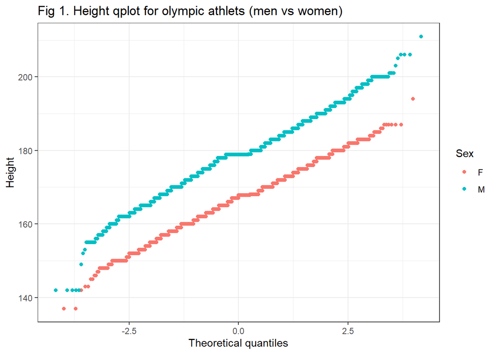

```r
Height_qplot <- qplot(sample = Height, data = olimpiad_file_filtered_winter, color = Sex) +
  scale_y_continuous(name = "Height") +
  scale_x_continuous(name = "Theoretical quantiles") +
  labs(title = "Fig 1. Height qplot for olympic athlets (men vs women)") +
  theme_bw()
Height_qplot
```

Let’s build Height density plot for athletes participating in Winter Olympic Games in sex specific manner:

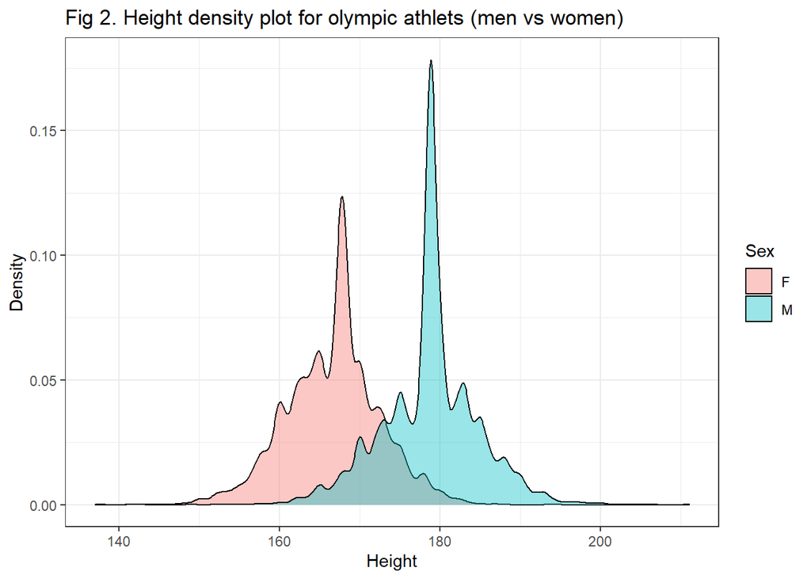

```r
Height_density <- ggplot(olimpiad_file_filtered_winter, aes(x = Height, fill = Sex)) +
  geom_density(alpha = 0.4) +
  scale_y_continuous(name = "Density") +
  scale_x_continuous(name = "Height") +
  labs(title = "Fig 2. Height density plot for olympic athlets (men vs women)") +
  theme_bw()
Height_density
```

Height qplot and density plot demonstrated Height normal distribution.

The peaks of the density plot corresponding to the average values appeared as a result of replacing a large number of NAs with the Height average value

Let’s build boxplot for athletes participating in Winter Olympic Games in sex specific manner:

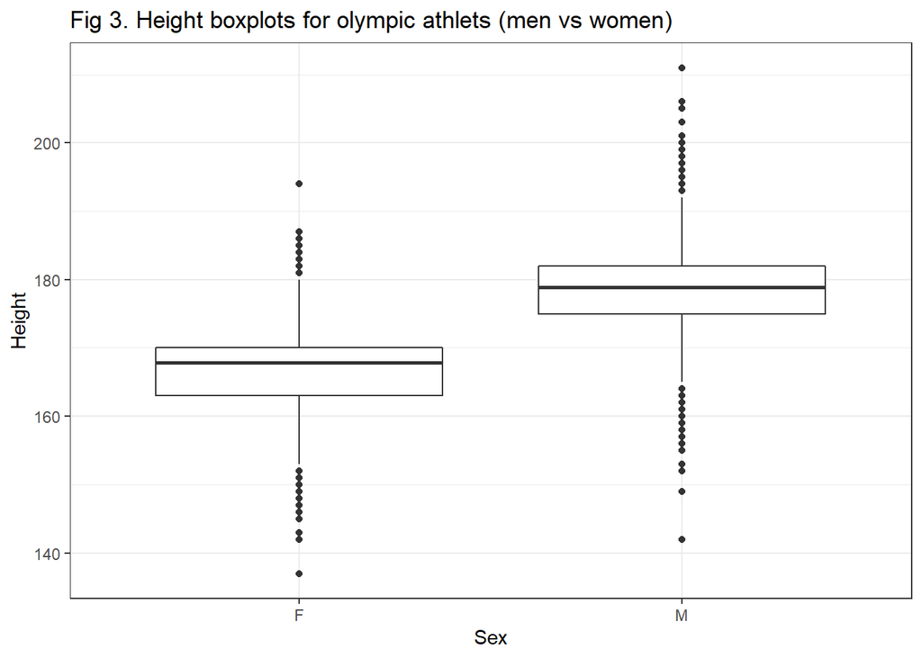

```r
Height_boxplot <- ggplot(olimpiad_file_filtered_winter, aes(x = Sex, y = Height, group=Sex)) +
  geom_boxplot() +
  scale_x_discrete(name = "Sex") +
  labs(title = "Fig 3. Height boxplots for olympic athlets (men vs women)") +
  theme_bw()
Height_boxplot
```

As height is normally distributed we can use t.test:

```r
t.test(x=olimpiad_file_filtered_winter$Height[olimpiad_file_filtered_winter$Sex == 'F'],
       y=olimpiad_file_filtered_winter$Height[olimpiad_file_filtered_winter$Sex == 'M'],
       alternative = c("two.sided"))
```

```
##
##  Welch Two Sample t-test
##
## data:  olimpiad_file_filtered_winter$Height[olimpiad_file_filtered_winter$Sex == "F"] and olimpiad_file_filtered_winter$Height[olimpiad_file_filtered_winter$Sex == "M"]
## t = -212.55, df = 29790, p-value < 2.2e-16
## alternative hypothesis: true difference in means is not equal to 0
## 95 percent confidence interval:
##  -12.15449 -11.93237
## sample estimates:
## mean of x mean of y
##  166.6639  178.7074
```

t = -212.55, p-value < 2.2e-16, therefore, men and women height differs statistically significantly

Let’s build Weight qplot for athletes participating in Winter Olympic Games in sex specific manner:

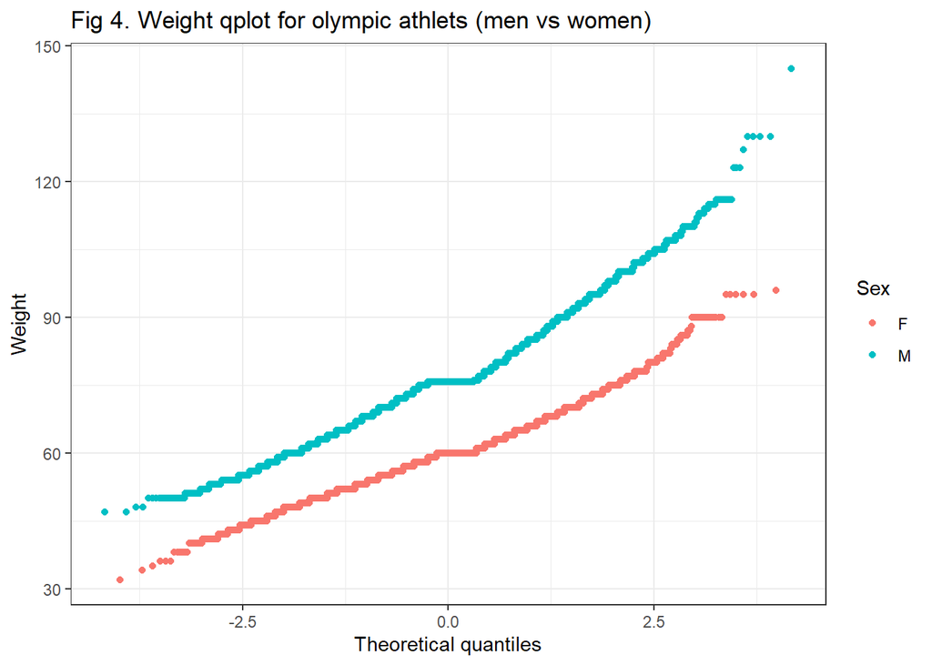

```r
Weight_qplot <- qplot(sample = Weight, data = olimpiad_file_filtered_winter, color = Sex) +
  scale_y_continuous(name = "Weight") +
  scale_x_continuous(name = "Theoretical quantiles") +
  labs(title = "Fig 4. Weight qplot for olympic athlets (men vs women)") +
  theme_bw()
Weight_qplot
```

Let’s build Weight density plot for athletes participating in Winter Olympic Games in sex specific manner:

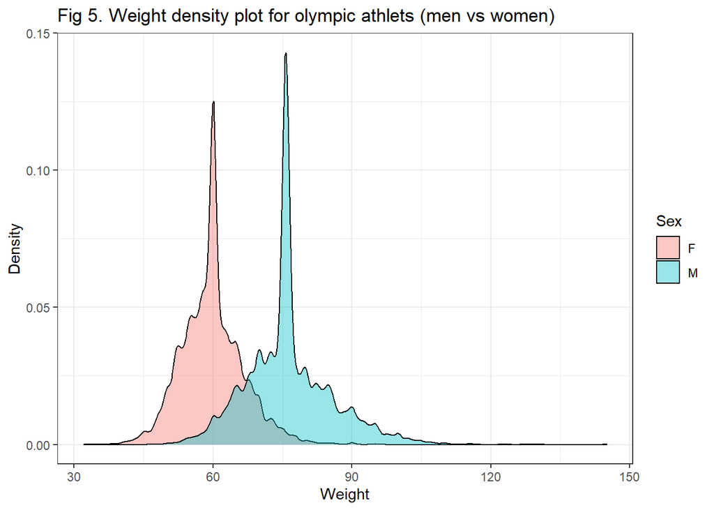

```r
Weight_density <- ggplot(olimpiad_file_filtered_winter, aes(x = Weight, fill = Sex)) +
  geom_density(alpha = 0.4) +
  scale_y_continuous(name = "Density") +
  scale_x_continuous(name = "Weight") +
  labs(title = "Fig 5. Weight density plot for olympic athlets (men vs women)") +
  theme_bw()
Weight_density
```

The peaks of the density plot corresponding to the average values appeared as a result of replacing a large number of NAs with the Weight average value

Let’s build Weight boxplot for athletes participating in Winter Olympic Games in sex specific manner:

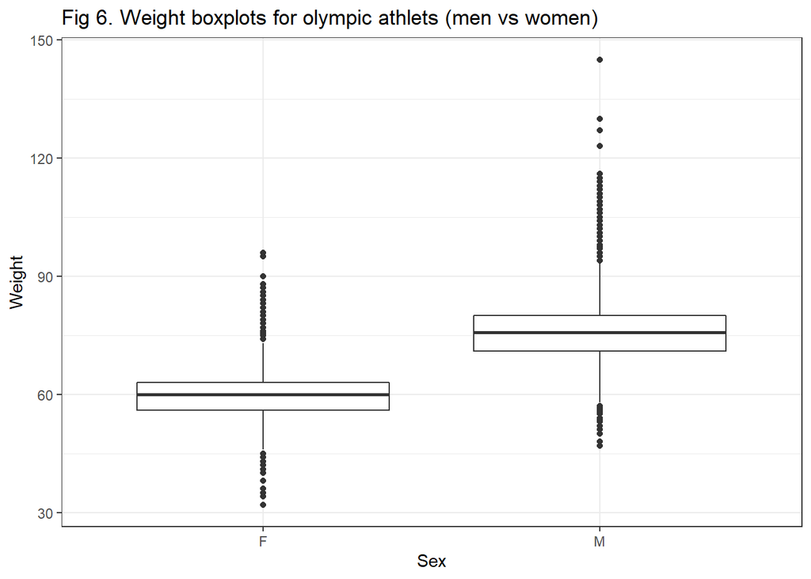

```r
Weight_boxplot <- ggplot(olimpiad_file_filtered_winter, aes(x = Sex, y = Weight, group=Sex)) +
  geom_boxplot() +
  scale_x_discrete(name = "Sex") +
  labs(title = "Fig 6. Weight boxplots for olympic athlets (men vs women)") +
  theme_bw()
Weight_boxplot
```

```r
t.test(x=olimpiad_file_filtered_winter$Weight[olimpiad_file_filtered_winter$Sex == 'F'],
       y=olimpiad_file_filtered_winter$Weight[olimpiad_file_filtered_winter$Sex == 'M'],
       alternative = c("two.sided"))
```

```
##
##  Welch Two Sample t-test
##
## data:  olimpiad_file_filtered_winter$Weight[olimpiad_file_filtered_winter$Sex == "F"] and olimpiad_file_filtered_winter$Weight[olimpiad_file_filtered_winter$Sex == "M"]
## t = -223.27, df = 39025, p-value < 2.2e-16
## alternative hypothesis: true difference in means is not equal to 0
## 95 percent confidence interval:
##  -16.58209 -16.29348
## sample estimates:
## mean of x mean of y
##  59.78632  76.22410
```

t = -223.27, p-value < 2.2e-16, therefore, men and women weight differs statistically significantly

Let’s build Age qplot for athletes participating in Winter Olympic Games in sex specific manner:

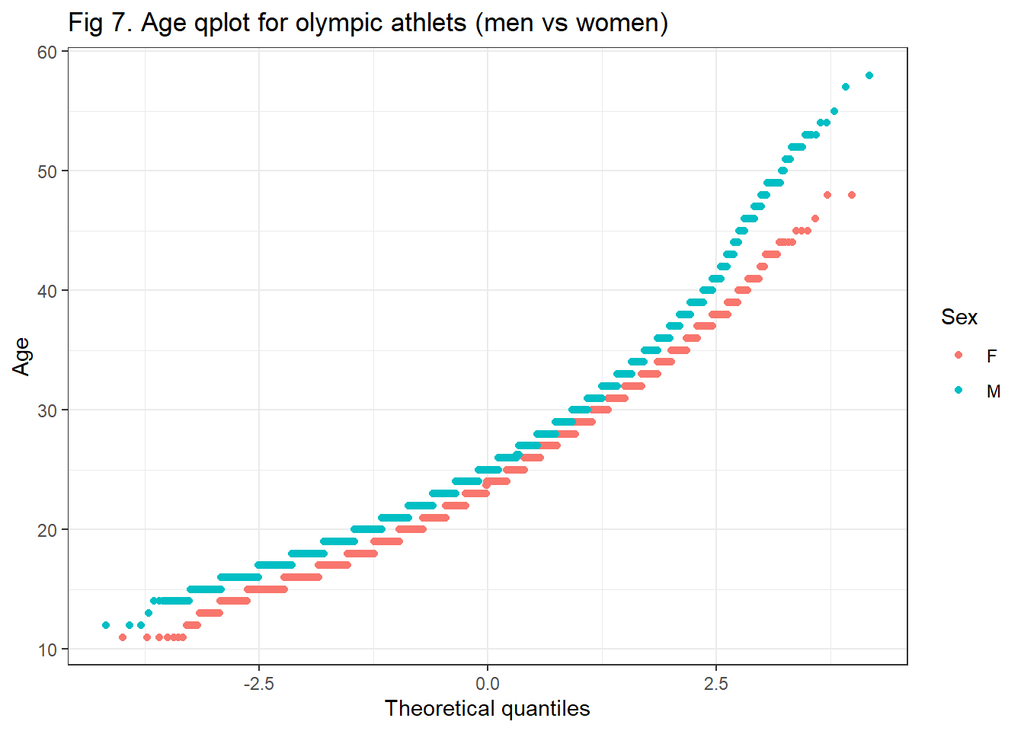

```r
Age_qplot <- qplot(sample = Age, data = olimpiad_file_filtered_winter, color = Sex) +
  scale_y_continuous(name = "Age") +
  scale_x_continuous(name = "Theoretical quantiles") +
  labs(title = "Fig 7. Age qplot for olympic athlets (men vs women)") +
  theme_bw()
Age_qplot
```

Let’s build Age density plot for athletes participating in Winter Olympic Games in sex specific manner:

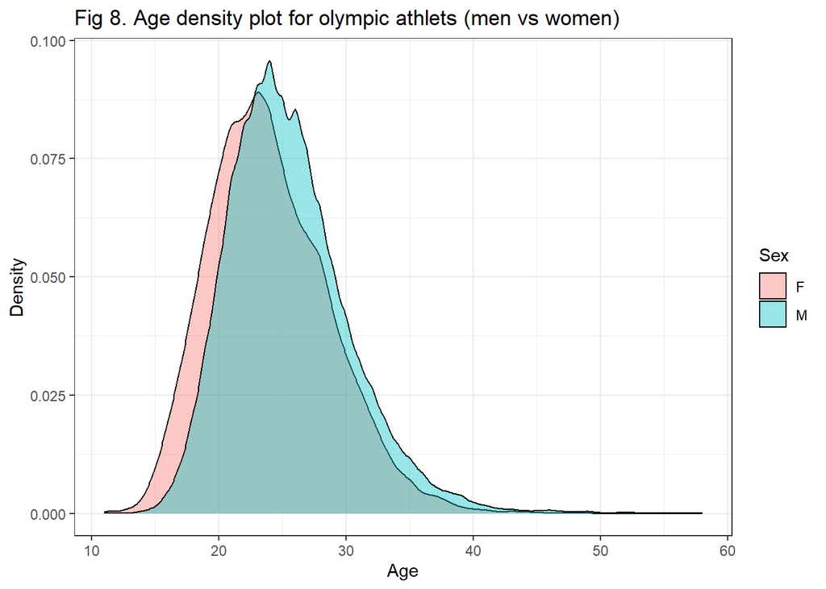

```r
Age_density <- ggplot(olimpiad_file_filtered_winter, aes(x = Age, fill = Sex)) +
  geom_density(alpha = 0.4) +
  scale_y_continuous(name = "Density") +
  scale_x_continuous(name = "Age") +
  labs(title = "Fig 8. Age density plot for olympic athlets (men vs women)") +
  theme_bw()
Age_density
```

Let’s build Age boxplot for athletes participating in Winter Olympic Games in sex specific manner:

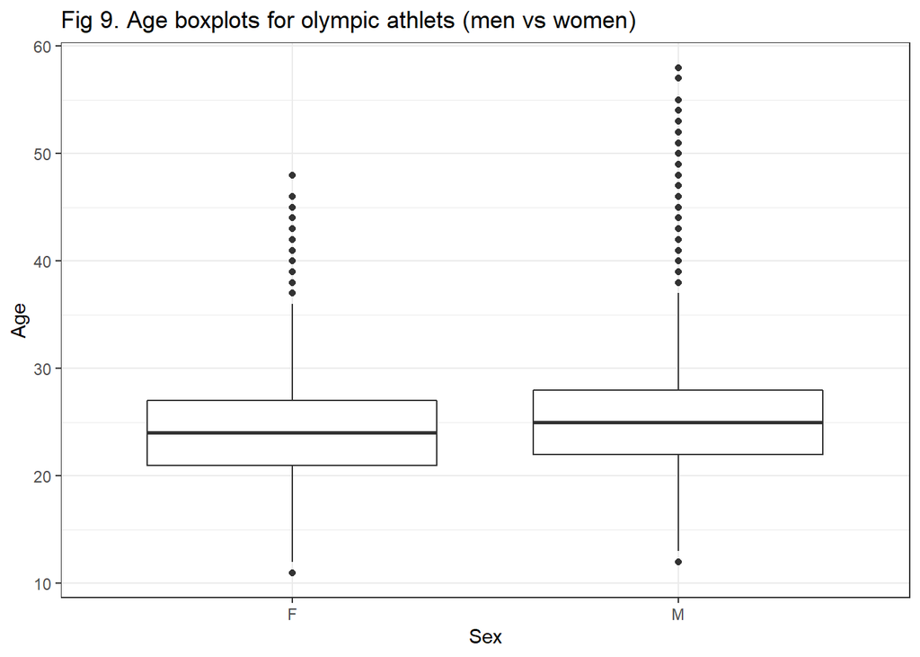

```r
Age_boxplot <- ggplot(olimpiad_file_filtered_winter, aes(x = Sex, y = Age, group=Sex)) +
  geom_boxplot() +
  scale_x_discrete(name = "Sex") +
  labs(title = "Fig 9. Age boxplots for olympic athlets (men vs women)") +
  theme_bw()
Age_boxplot
```

```r
t.test(x=olimpiad_file_filtered_winter$Age[olimpiad_file_filtered_winter$Sex == 'F'],
       y=olimpiad_file_filtered_winter$Age[olimpiad_file_filtered_winter$Sex == 'M'],
       alternative = c("two.sided"))
```

```
##
##  Welch Two Sample t-test
##
## data:  olimpiad_file_filtered_winter$Age[olimpiad_file_filtered_winter$Sex == "F"] and olimpiad_file_filtered_winter$Age[olimpiad_file_filtered_winter$Sex == "M"]
## t = -32.476, df = 29281, p-value < 2.2e-16
## alternative hypothesis: true difference in means is not equal to 0
## 95 percent confidence interval:
##  -1.587094 -1.406422
## sample estimates:
## mean of x mean of y
##  24.01407  25.51082
```

t = -32.476, p-value < 2.2e-16, therefore, men and women ago differs statistically significantly

### Task 15

Let’s tets the Team and Medal linkage existence using Chi-squared test:

```r
chisq.test(olimpiad_file_filtered$Team, olimpiad_file_filtered$Medal)
```

```
##
##  Pearson's Chi-squared test
##
## data:  olimpiad_file_filtered$Team and olimpiad_file_filtered$Medal
## X-squared = 5288.9, df = 992, p-value < 2.2e-16
```

We found some linkage between Team and Medal (X-squared = 5288.9, p-value < 2.2e-16).

It is also supported with the fact that some countries (e.g. USA) generally receive more medals than the vast majority of other teams every Olympic Games event

### Task 16

#### Let’s research if correlation between athletes Height and Weight exists

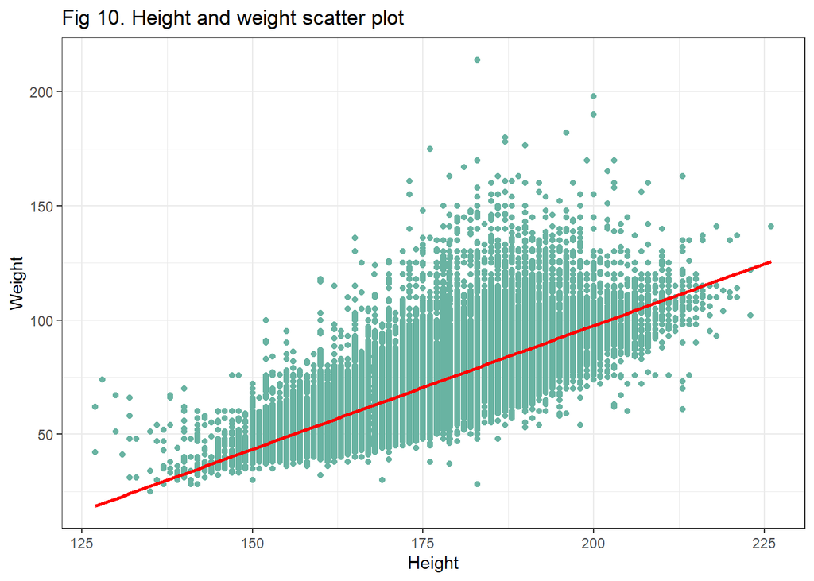

```r
ggplot(olimpiad_file_filtered, aes(x = Height, y = Weight)) +
         geom_point(color="#69b3a2") +
         geom_smooth(method=lm , color="red", size = 1) +
         labs(title = "Fig 10. Height and weight scatter plot") +
         theme_bw()
```

From these plot we can notice that some correlation between Height and Weight exists, but how strong?

To test it we can use correlation test:

```r
cor.test(olimpiad_file_filtered$Height, olimpiad_file_filtered$Weight)
```

```
##
##  Pearson's product-moment correlation
##
## data:  olimpiad_file_filtered$Height and olimpiad_file_filtered$Weight
## t = 680.89, df = 267524, p-value < 2.2e-16
## alternative hypothesis: true correlation is not equal to 0
## 95 percent confidence interval:
##  0.7949099 0.7976830
## sample estimates:
##       cor
## 0.7963006
```

We can notice strong correlation between Height and Weight (cor = 0.7963006, p-value < 2.2e-16)

#### Let’s test the difference in features for athletes participating in Summer and Winter Olympic Games

Let’s transform Season column to factor and check the data table structure:

```r
olimpiad_file_filtered$Season <- as.factor(olimpiad_file_filtered$Season)
str(olimpiad_file_filtered)
```

```
## 'data.frame':    267526 obs. of  17 variables:
##  $ ID                   : num  5 5 5 5 5 5 8 8 13 13 ...
##  $ Name                 : chr  "Christine Jacoba Aaftink" "Christine Jacoba Aaftink" "Christine Jacoba Aaftink" "Christine Jacoba Aaftink" ...
##  $ Sex                  : Factor w/ 2 levels "F","M": 1 1 1 1 1 1 1 1 1 1 ...
##  $ Age                  : num  21 21 25 25 27 27 18 18 30 34 ...
##  $ Height               : num  185 185 185 185 185 185 168 168 159 159 ...
##  $ Weight               : num  82 82 82 82 82 ...
##  $ Team                 : chr  "Netherlands" "Netherlands" "Netherlands" "Netherlands" ...
##  $ NOC                  : chr  "NED" "NED" "NED" "NED" ...
##  $ Games                : chr  "1988 Winter" "1988 Winter" "1992 Winter" "1992 Winter" ...
##  $ Year                 : int  1988 1988 1992 1992 1994 1994 1932 1932 1996 2000 ...
##  $ Season               : Factor w/ 2 levels "Summer","Winter": 2 2 2 2 2 2 1 1 1 1 ...
##  $ City                 : chr  "Calgary" "Calgary" "Albertville" "Albertville" ...
##  $ Sport                : chr  "Speed Skating" "Speed Skating" "Speed Skating" "Speed Skating" ...
##  $ Event                : chr  "Speed Skating Women's 500 metres" "Speed Skating Women's 1,000 metres" "Speed Skating Women's 500 metres" "Speed Skating Women's 1,000 metres" ...
##  $ Medal                : chr  NA NA NA NA ...
##  $ Height_z_scores      : num  0.965 0.965 0.965 0.965 0.965 ...
##  $ Height_min_max_scaled: num  0.586 0.586 0.586 0.586 0.586 ...
```

Let’s build density plots for Height, Weight and Ago columns for athletes participating in Summer and Winter Olympic Games

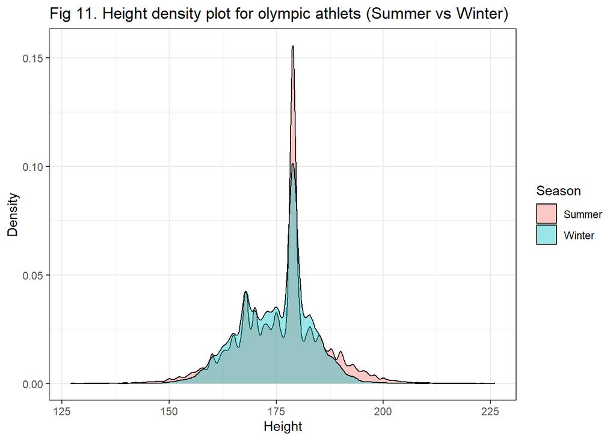

```r
Height_density <- ggplot(olimpiad_file_filtered, aes(x = Height, fill = Season)) +
  geom_density(alpha = 0.4) +
  scale_y_continuous(name = "Density") +
  scale_x_continuous(name = "Height") +
  labs(title = "Fig 11. Height density plot for olympic athlets (Summer vs Winter)") +
  theme_bw()
Height_density
```

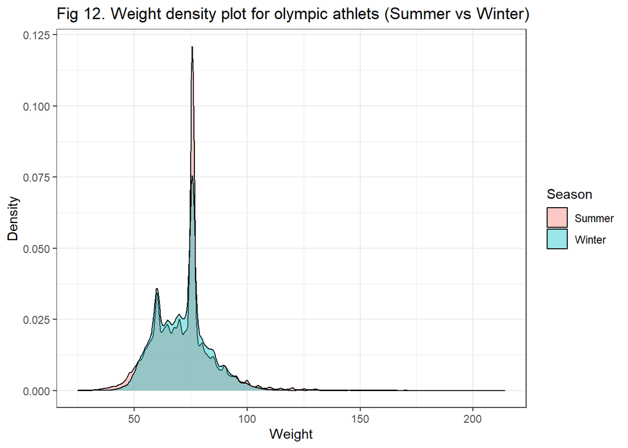

```r
Weight_density <- ggplot(olimpiad_file_filtered, aes(x = Weight, fill = Season)) +
  geom_density(alpha = 0.4) +
  scale_y_continuous(name = "Density") +
  scale_x_continuous(name = "Weight") +
  labs(title = "Fig 12. Weight density plot for olympic athlets (Summer vs Winter)") +
  theme_bw()
Weight_density
```

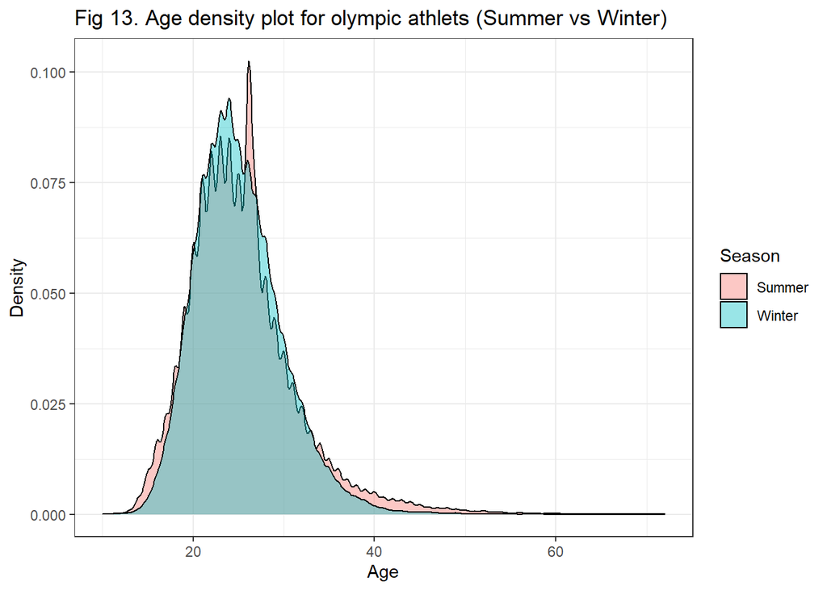

```r
Age_density <- ggplot(olimpiad_file_filtered, aes(x = Age, fill = Season)) +
  geom_density(alpha = 0.4) +
  scale_y_continuous(name = "Density") +
  scale_x_continuous(name = "Age") +
  labs(title = "Fig 13. Age density plot for olympic athlets (Summer vs Winter)") +
  theme_bw()
Age_density
```

Let’s build boxplots for Height, Weight and Ago columns for athletes participating in Summer and Winter Olympic Games

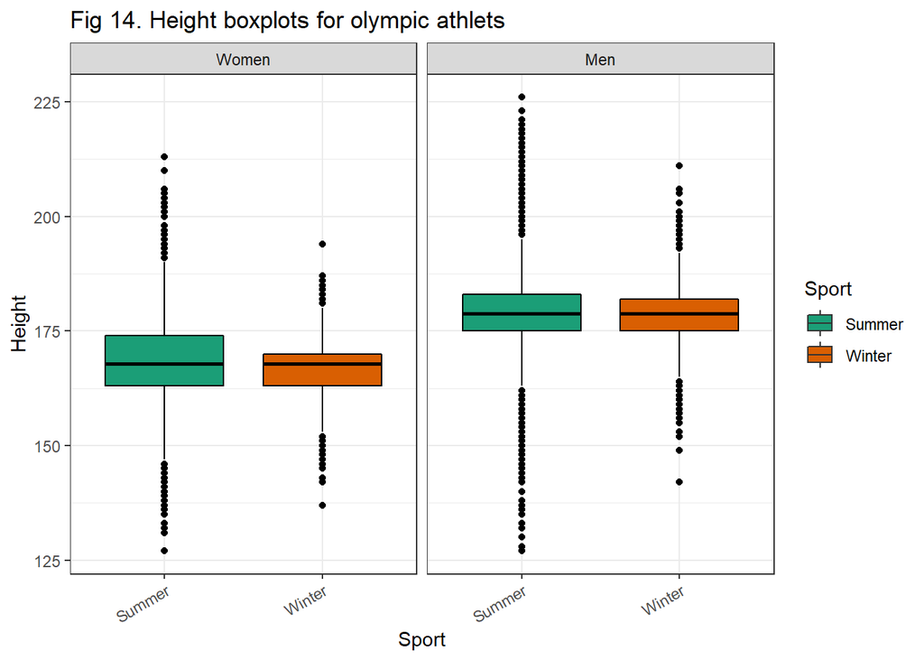

```r
facet_names <- as_labeller(c(`M` = "Men", `F` = "Women"))
boxplot_sport <- ggplot(olimpiad_file_filtered, aes(x = Season, y = Height, fill = Season, color = I("black"), size=I(.5))) +
  geom_boxplot() +
  facet_grid(cols = vars(Sex), labeller = facet_names) +
  scale_fill_brewer(type = "qual", palette = 2, name = "Sport") +
  scale_x_discrete(name = "Sport", guide = guide_axis(angle = 30)) +
  scale_y_continuous(name = "Height") + labs(title = "Fig 14. Height boxplots for olympic athlets") +
  theme_bw()
boxplot_sport
```

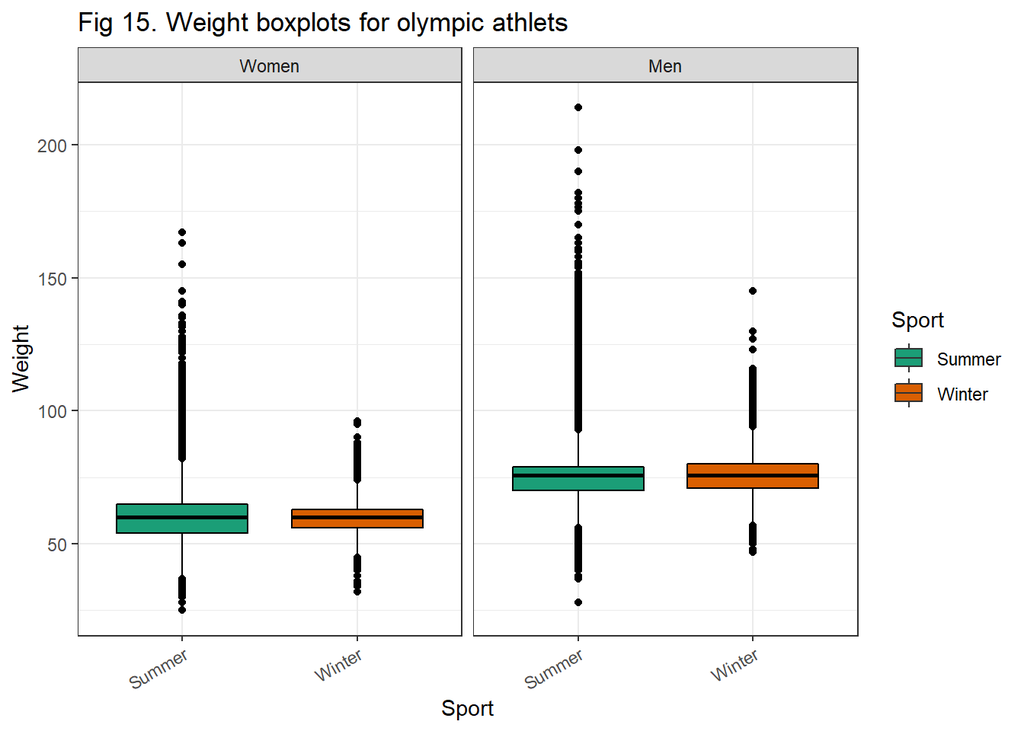

```r
boxplot_sport <- ggplot(olimpiad_file_filtered, aes(x = Season, y = Weight, fill = Season, color = I("black"), size=I(.5))) +
  geom_boxplot() +
  facet_grid(cols = vars(Sex), labeller = facet_names) +
  scale_fill_brewer(type = "qual", palette = 2, name = "Sport") +
  scale_x_discrete(name = "Sport", guide = guide_axis(angle = 30)) +
  scale_y_continuous(name = "Weight") + labs(title = "Fig 15. Weight boxplots for olympic athlets") +
  theme_bw()
boxplot_sport
```

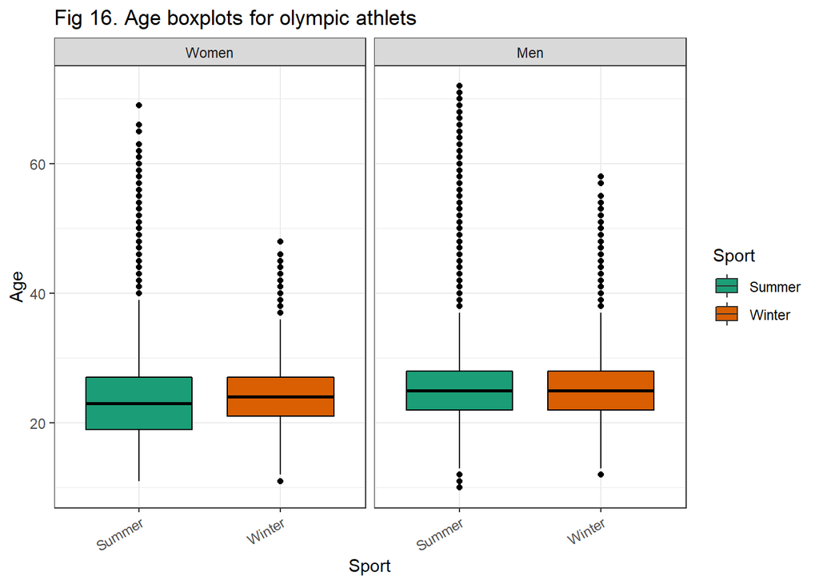

```r
boxplot_sport <- ggplot(olimpiad_file_filtered, aes(x = Season, y = Age, fill = Season, color = I("black"), size=I(.5))) +
  geom_boxplot() +
  facet_grid(cols = vars(Sex), labeller = facet_names) +
  scale_fill_brewer(type = "qual", palette = 2, name = "Sport") +
  scale_x_discrete(name = "Sport", guide = guide_axis(angle = 30)) +
  scale_y_continuous(name = "Age") + labs(title = "Fig 16. Age boxplots for olympic athlets") +
  theme_bw()
boxplot_sport
```

We can notice form builded density plots and boxplots, that differences in distributions are linked only with sex (men or women) instead of season (Winter or Summer)

#### Analysis of the most popular kinds of sport

After analysis of kinds of sport presented in Summer or Winter Olympic Games we decided to take a deeper look at the most popular kinds of sport with more than 10 000 rows in our data (Gymnastics, Swimming, Athletics, Fencing, Cycling, Shooting)

First, transform Sport column to factor and filter data:

```r
olimpiad_file_filtered$Sport <- as.factor(olimpiad_file_filtered$Sport)

olimpiad_file_filtered_sport <- olimpiad_file_filtered %>%
  filter(Sport %in% c('Gymnastics', 'Swimming', 'Athletics', 'Fencing', 'Cycling',
                    'Shooting'))
```

Let’s build Height and Weight scatter plot for these kinds of sport:

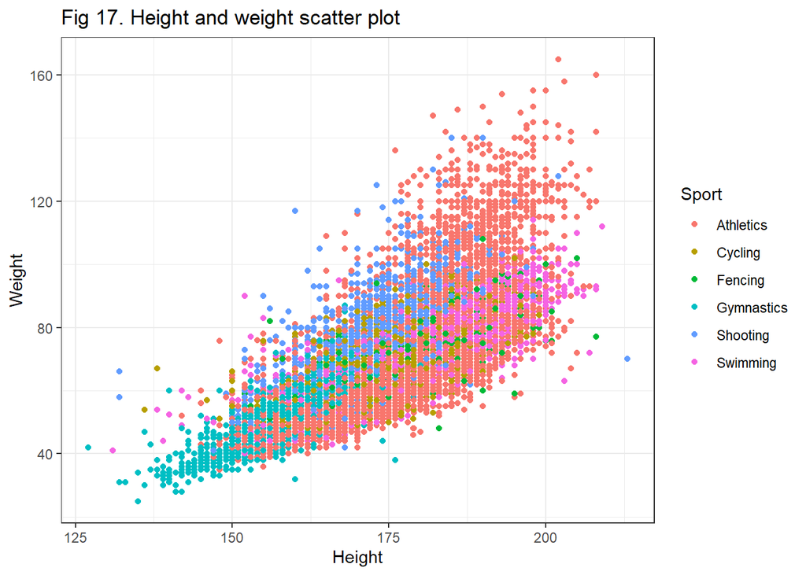

```r
ggplot(olimpiad_file_filtered_sport, aes(x = Height, y = Weight)) +
         geom_point(aes(color=Sport)) +
         labs(title = "Fig 17. Height and weight scatter plot") +
         theme_bw()
```

We can notice, that these points are widely distributed despite on the clustering attempts

Athletics is the most widely distributed possibly because its internal division into light athletics and weightlifting

Let’s build Ago violin plots and boxplots

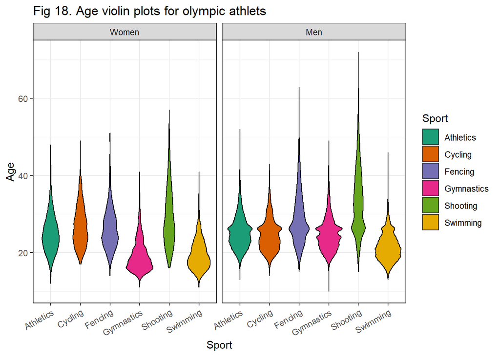

```r
facet_names <- as_labeller(c(`M` = "Men", `F` = "Women"))

violin_sport <- ggplot(olimpiad_file_filtered_sport, aes(x = Sport, y = Age, fill = Sport, color = I("black"), size=I(.5))) +
  geom_violin() +
  facet_grid(cols = vars(Sex), labeller = facet_names) +
  scale_fill_brewer(type = "qual", palette = 2, name = "Sport") +
  scale_x_discrete(name = "Sport", guide = guide_axis(angle = 30)) +
  scale_y_continuous(name = "Age") + labs(title = "Fig 18. Age violin plots for olympic athlets") +
  theme_bw()
violin_sport
```

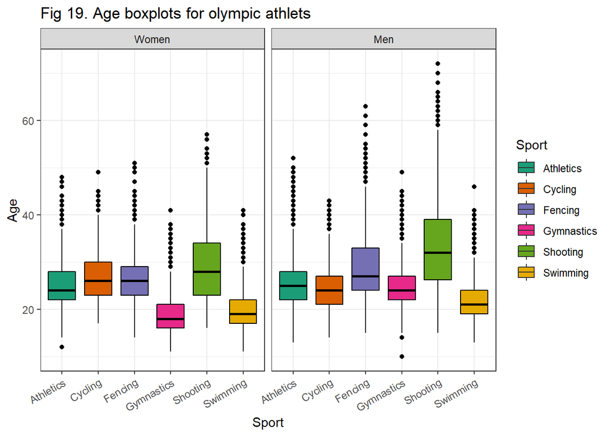

```r
facet_names <- as_labeller(c(`M` = "Men", `F` = "Women"))

boxplot_sport <- ggplot(olimpiad_file_filtered_sport, aes(x = Sport, y = Age, fill = Sport, color = I("black"), size=I(.5))) +
  geom_boxplot() +
  facet_grid(cols = vars(Sex), labeller = facet_names) +
  scale_fill_brewer(type = "qual", palette = 2, name = "Sport") +
  scale_x_discrete(name = "Sport", guide = guide_axis(angle = 30)) +
  scale_y_continuous(name = "Age") + labs(title = "Fig 19. Age boxplots for olympic athlets") +
  theme_bw()
boxplot_sport
```

We can notice the difference between Shooting and Swimming, Shooting and Gymnastics both for men and women. Women participating in Gymnastics seems to be younger in average than in Athletics, Cycling or Fencing.

Making pairwise comparisons in multiple comparisons is a bad habit, but it’s hard to resist the temptation.

Let’s test the difference between Shooting and Swimming Women athletes:

```r
t.test(x=olimpiad_file_filtered_sport$Age[olimpiad_file_filtered_sport$Sport == 'Shooting' &
                                            olimpiad_file_filtered_sport$Sex == 'F'],
       y=olimpiad_file_filtered_sport$Age[olimpiad_file_filtered_sport$Sport == 'Swimming' &
                                            olimpiad_file_filtered_sport$Sex == 'F'],
       alternative = c("two.sided"))
```

```
##
##  Welch Two Sample t-test
##
## data:  olimpiad_file_filtered_sport$Age[olimpiad_file_filtered_sport$Sport == "Shooting" & olimpiad_file_filtered_sport$Sex == "F"] and olimpiad_file_filtered_sport$Age[olimpiad_file_filtered_sport$Sport == "Swimming" & olimpiad_file_filtered_sport$Sex == "F"]
## t = 51.474, df = 1875.9, p-value < 2.2e-16
## alternative hypothesis: true difference in means is not equal to 0
## 95 percent confidence interval:
##  9.222541 9.953159
## sample estimates:
## mean of x mean of y
##  29.11280  19.52495
```

Let’s test the difference between Shooting and Swimming Men athletes:

```r
t.test(x=olimpiad_file_filtered_sport$Age[olimpiad_file_filtered_sport$Sport == 'Shooting' &
                                            olimpiad_file_filtered_sport$Sex == 'M'],
       y=olimpiad_file_filtered_sport$Age[olimpiad_file_filtered_sport$Sport == 'Swimming' &
                                            olimpiad_file_filtered_sport$Sex == 'M'],
       alternative = c("two.sided"))
```

```
##
##  Welch Two Sample t-test
##
## data:  olimpiad_file_filtered_sport$Age[olimpiad_file_filtered_sport$Sport == "Shooting" & olimpiad_file_filtered_sport$Sex == "M"] and olimpiad_file_filtered_sport$Age[olimpiad_file_filtered_sport$Sport == "Swimming" & olimpiad_file_filtered_sport$Sex == "M"]
## t = 132.46, df = 12241, p-value < 2.2e-16
## alternative hypothesis: true difference in means is not equal to 0
## 95 percent confidence interval:
##  11.86215 12.21849
## sample estimates:
## mean of x mean of y
##  33.58260  21.54228
```

Let’s test the difference between Shooting and Gymnastics Women athletes:

```r
t.test(x=olimpiad_file_filtered_sport$Age[olimpiad_file_filtered_sport$Sport == 'Shooting' &
                                            olimpiad_file_filtered_sport$Sex == 'F'],
       y=olimpiad_file_filtered_sport$Age[olimpiad_file_filtered_sport$Sport == 'Gymnastics' &
                                            olimpiad_file_filtered_sport$Sex == 'F'],
       alternative = c("two.sided"))
```

```
##
##  Welch Two Sample t-test
##
## data:  olimpiad_file_filtered_sport$Age[olimpiad_file_filtered_sport$Sport == "Shooting" & olimpiad_file_filtered_sport$Sex == "F"] and olimpiad_file_filtered_sport$Age[olimpiad_file_filtered_sport$Sport == "Gymnastics" & olimpiad_file_filtered_sport$Sex == "F"]
## t = 52.583, df = 1909, p-value < 2.2e-16
## alternative hypothesis: true difference in means is not equal to 0
## 95 percent confidence interval:
##   9.470972 10.204826
## sample estimates:
## mean of x mean of y
##   29.1128   19.2749
```

Let’s test the difference between Shooting and Gymnastics Men athletes:

```r
t.test(x=olimpiad_file_filtered_sport$Age[olimpiad_file_filtered_sport$Sport == 'Shooting' &
                                            olimpiad_file_filtered_sport$Sex == 'M'],
       y=olimpiad_file_filtered_sport$Age[olimpiad_file_filtered_sport$Sport == 'Gymnastics' &
                                            olimpiad_file_filtered_sport$Sex == 'M'],
       alternative = c("two.sided"))
```

```
##
##  Welch Two Sample t-test
##
## data:  olimpiad_file_filtered_sport$Age[olimpiad_file_filtered_sport$Sport == "Shooting" & olimpiad_file_filtered_sport$Sex == "M"] and olimpiad_file_filtered_sport$Age[olimpiad_file_filtered_sport$Sport == "Gymnastics" & olimpiad_file_filtered_sport$Sex == "M"]
## t = 96.946, df = 12358, p-value < 2.2e-16
## alternative hypothesis: true difference in means is not equal to 0
## 95 percent confidence interval:
##  8.649481 9.006466
## sample estimates:
## mean of x mean of y
##  33.58260  24.75463
```

Let’s test the difference between Fencing and Cycling Women athletes which are visually does not differ:

```r
t.test(x=olimpiad_file_filtered_sport$Age[olimpiad_file_filtered_sport$Sport == 'Fencing' &
                                            olimpiad_file_filtered_sport$Sex == 'F'],
       y=olimpiad_file_filtered_sport$Age[olimpiad_file_filtered_sport$Sport == 'Cycling' &
                                            olimpiad_file_filtered_sport$Sex == 'F'],
       alternative = c("two.sided"))
```

```
##
##  Welch Two Sample t-test
##
## data:  olimpiad_file_filtered_sport$Age[olimpiad_file_filtered_sport$Sport == "Fencing" & olimpiad_file_filtered_sport$Sex == "F"] and olimpiad_file_filtered_sport$Age[olimpiad_file_filtered_sport$Sport == "Cycling" & olimpiad_file_filtered_sport$Sex == "F"]
## t = -3.2656, df = 2999.9, p-value = 0.001105
## alternative hypothesis: true difference in means is not equal to 0
## 95 percent confidence interval:
##  -0.9501378 -0.2372146
## sample estimates:
## mean of x mean of y
##  26.30589  26.89957
```

Let’s build Height boxplots

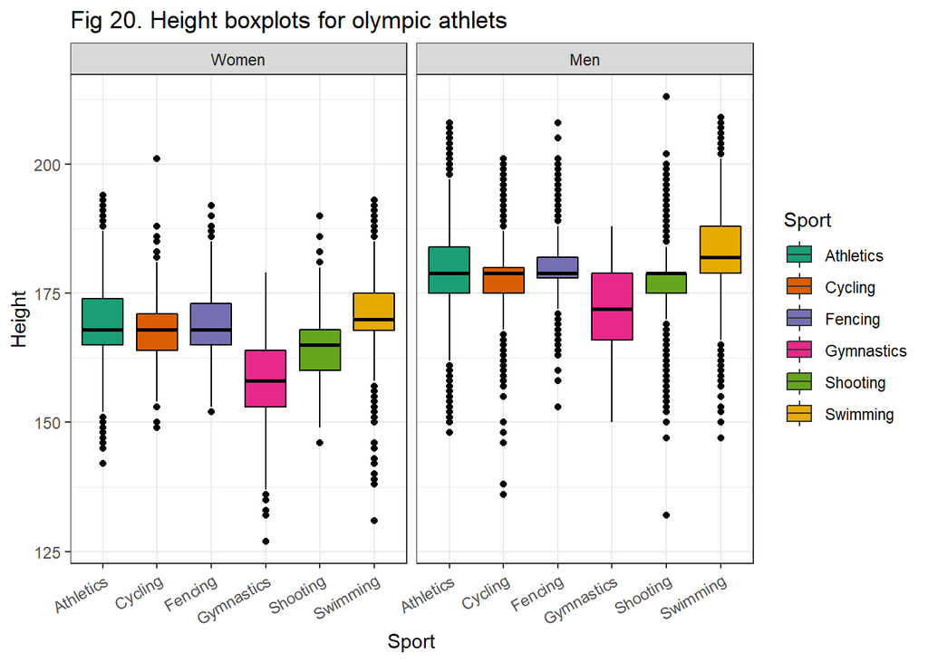

```r
boxplot_sport <- ggplot(olimpiad_file_filtered_sport, aes(x = Sport, y = Height, fill = Sport, color = I("black"), size=I(.5))) +
  geom_boxplot() +
  facet_grid(cols = vars(Sex), labeller = facet_names) +
  scale_fill_brewer(type = "qual", palette = 2, name = "Sport") +
  scale_x_discrete(name = "Sport", guide = guide_axis(angle = 30)) +
  scale_y_continuous(name = "Height") + labs(title = "Fig 20. Height boxplots for olympic athlets") +
  theme_bw()
boxplot_sport
```

We can notice that in average athletes participating in Gymnastics are smaller than in Athletics, Cycling or Fencing and athletes participating in Swimming are taller than in Gymnastics. First observation can be explained with the fact that athletes participating in Gymnastics are usually younger than others except swimmers. Possibly, for swimmers young age and higth Height are crucial features helping them to compete in Olympic Games

Let’s build Weight boxplots

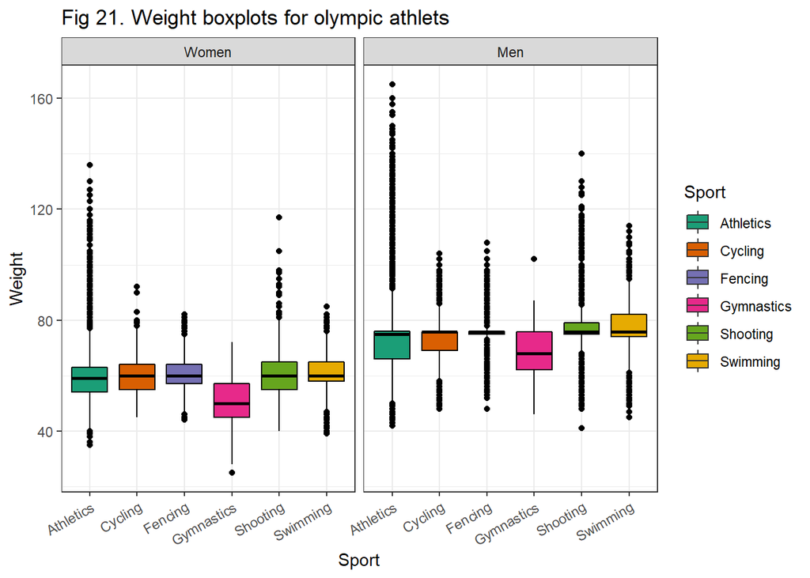

```r
boxplot_sport <- ggplot(olimpiad_file_filtered_sport, aes(x = Sport, y = Weight, fill = Sport, color = I("black"), size=I(.5))) +
  geom_boxplot() +
  facet_grid(cols = vars(Sex), labeller = facet_names) +
  scale_fill_brewer(type = "qual", palette = 2, name = "Sport") +
  scale_x_discrete(name = "Sport", guide = guide_axis(angle = 30)) +
  scale_y_continuous(name = "Weight") + labs(title = "Fig 21. Weight boxplots for olympic athlets") +
  theme_bw()
boxplot_sport
```

We can notice that in average women athletes participating in Gymnastics are lighter in weight than in other disciplines May be can be explained with the fact that athletes participating in Gymnastics are usually younger than others except swimmers. Possibly, for gymnasts the lighter in weight the more successful in Olympic Games they can be.